# WOPINS Sexuality Analysis

## Models of Friendship

```
##
## ERGMs for Friendship
## ============================================================
##                                     Unit 2        Unit 3
##                                      (1)            (2)
## ------------------------------------------------------------
## edges                             -6.222***      -3.672**
##                                    (1.421)        (1.580)
##
## mutual                             1.428***      1.887***
##                                    (0.210)        (0.267)
##
## twopath                           -0.141***      -0.200***
##                                    (0.015)        (0.019)
##
## gwideg.fixed.1.5                    0.169         -0.540*
##                                    (0.327)        (0.324)
##
## gwesp.OTP.fixed.0.75               1.176***      1.206***
##                                    (0.076)        (0.086)
##
## nodeifactor.sex_minority.1          0.174          0.007
##                                    (0.118)        (0.108)
##
## nodeofactor.sex_minority.1         0.235**        -0.006
##                                    (0.111)        (0.117)
##
## nodematch.sex_minority              -0.049         0.083
##                                    (0.112)        (0.101)
##
## nodeifactor.prismom.1               0.008          0.181
##                                    (0.141)        (0.292)
##
## nodeofactor.prismom.1              -0.283**       -0.303
##                                    (0.120)        (0.287)
##
## nodematch.prismom                   -0.028         0.065
##                                    (0.125)        (0.282)
##
## nodeicov.sexacceptance_reverse      -0.069         0.086
```

[output cut: 61 more lines]

```
##
## nodeicov.MentalPhysicalHealth       0.149*         0.108
##                                    (0.081)        (0.084)
##
## nodeocov.MentalPhysicalHealth       -0.101        -0.059
##                                    (0.078)        (0.095)
##
## absdiff.MentalPhysicalHealth        -0.092         0.060
##                                    (0.092)        (0.111)
##
## ------------------------------------------------------------
## Akaike Inf. Crit.                 2,078.945      1,463.636
## Bayesian Inf. Crit.               2,298.404      1,674.780
## ============================================================
## Note:                            *p<0.1; **p<0.05; ***p<0.01
```

### Interpretation

#### Unit 2

- A positive `nodeofactor.sex_minority.1` term indicates that sexual minority women are more likely to send friendship ties
- A negative `nodeofactor.prismom` term indicates that prison mom’s are less likely to send a friendship tie
- A positive `nodeocov.sexacceptance_reverse` term indicates that those who are more accepting of sexual orientation are more likely to send a friendship tie (*check significance level)

#### Unit 3

No significant effects for the *sexual minority*, *prison mom*, or *acceptance of sexual orientation* variables.

## Models of Power/Influence

```
##
## ERGMs for Power/Influence
## ============================================================
##                                     Unit 2        Unit 3
##                                      (1)            (2)
## ------------------------------------------------------------
## edges                               -3.960         0.837
##                                    (2.749)        (3.099)
##
## mutual                             -Inf.000        0.921
##                                                   (0.562)
##
## twopath                           -0.257***      -0.096**
##                                    (0.065)        (0.049)
##
## gwideg.fixed.1.25                 -3.136***      -2.394***
##                                    (0.332)        (0.369)
##
## gwesp.OTP.fixed.0.75               1.075***       0.351*
##                                    (0.210)        (0.186)
##
## edgecov.f.net                      2.207***      2.288***
##                                    (0.213)        (0.224)
##
## nodeifactor.sex_minority.1          -0.176        -0.066
##                                    (0.184)        (0.198)
##
## nodeofactor.sex_minority.1          -0.087        -0.228
##                                    (0.269)        (0.255)
##
## nodematch.sex_minority              0.146         -0.073
##                                    (0.271)        (0.222)
##
## nodeicov.sexacceptance_reverse     -0.171**       -0.048
##                                    (0.069)        (0.079)
##
## nodeocov.sexacceptance_reverse      -0.158        -0.039
##                                    (0.104)        (0.105)
##
## absdiff.sexacceptance_reverse       -0.015        -0.095
```

[output cut: 55 more lines]

```
##
## nodeicov.MentalPhysicalHealth       -0.110        -0.008
##                                    (0.103)        (0.151)
##
## nodeocov.MentalPhysicalHealth       0.014          0.227
##                                    (0.187)        (0.201)
##
## absdiff.MentalPhysicalHealth        -0.112        -0.248
##                                    (0.194)        (0.225)
##
## ------------------------------------------------------------
## Akaike Inf. Crit.                                 757.959
## Bayesian Inf. Crit.                               957.038
## ============================================================
## Note:                            *p<0.1; **p<0.05; ***p<0.01
```

### Interpretation

#### Unit 2

- A negative `nodeicov.sexacceptance_reverse` term indicates that those who are more accepting of sexual orientation are less likely to receive power/influence ties; or, put differently: women who are less accepting of sexual orientation are more likely to receive power/influence ties.

## Goodness of Fit

```
##
## Goodness-of-fit for in-degree
##
##           obs min  mean max MC p-value
## idegree0   33  28 37.61  46       0.18
## idegree1   12   4  9.69  19       0.44
## idegree2   10   0  3.44   7       0.00
## idegree3    2   0  1.91   5       1.00
## idegree4    1   0  1.24   5       1.00
## idegree5    0   0  1.15   5       0.60
## idegree6    0   0  0.83   4       0.78
## idegree7    1   0  0.85   3       1.00
## idegree8    0   0  0.84   4       0.82
## idegree9    1   0  0.87   3       1.00
## idegree10   0   0  0.64   3       1.00
## idegree11   0   0  0.66   3       1.00
## idegree12   0   0  0.60   3       1.00
## idegree13   0   0  0.61   2       1.00
## idegree14   0   0  0.54   3       1.00
## idegree15   2   0  0.44   3       0.14
## idegree16   0   0  0.41   3       1.00
## idegree17   0   0  0.23   2       1.00
## idegree18   0   0  0.17   3       1.00
## idegree19   0   0  0.14   2       1.00
## idegree20   0   0  0.07   1       1.00
## idegree21   0   0  0.04   1       1.00
## idegree22   0   0  0.01   1       1.00
## idegree23   0   0  0.01   1       1.00
## idegree33   1   0  0.00   0       0.00
##
## Goodness-of-fit for out-degree
##
##           obs min  mean max MC p-value
## odegree0   10   8 14.81  23       0.22
## odegree1   15   8 16.45  23       0.78
## odegree2   18   6 13.53  22       0.20
## odegree3   13   3  8.36  14       0.16
## odegree4    5   0  4.57  11       1.00
## odegree5    1   0  2.55   7       0.50
## odegree6    1   0  1.11   5       1.00
```

[output cut: 96 more lines]

```
## nodeicov.unitdays100                  0.88
## nodeocov.unitdays100                  0.92
## absdiff.unitdays100                   0.86
## nodeifactor.prismom.1                 0.96
## nodeofactor.prismom.1                 1.00
## nodematch.prismom                     0.94
## nodeicov.grade                        0.92
## nodeocov.grade                        0.94
## absdiff.grade                         1.00
## nodeifactor.white.1                   1.00
## nodeofactor.white.1                   0.94
## nodematch.white                       1.00
## nodeifactor.protestantbinary.1        0.96
## nodeofactor.protestantbinary.1        0.94
## nodematch.protestantbinary            0.84
```

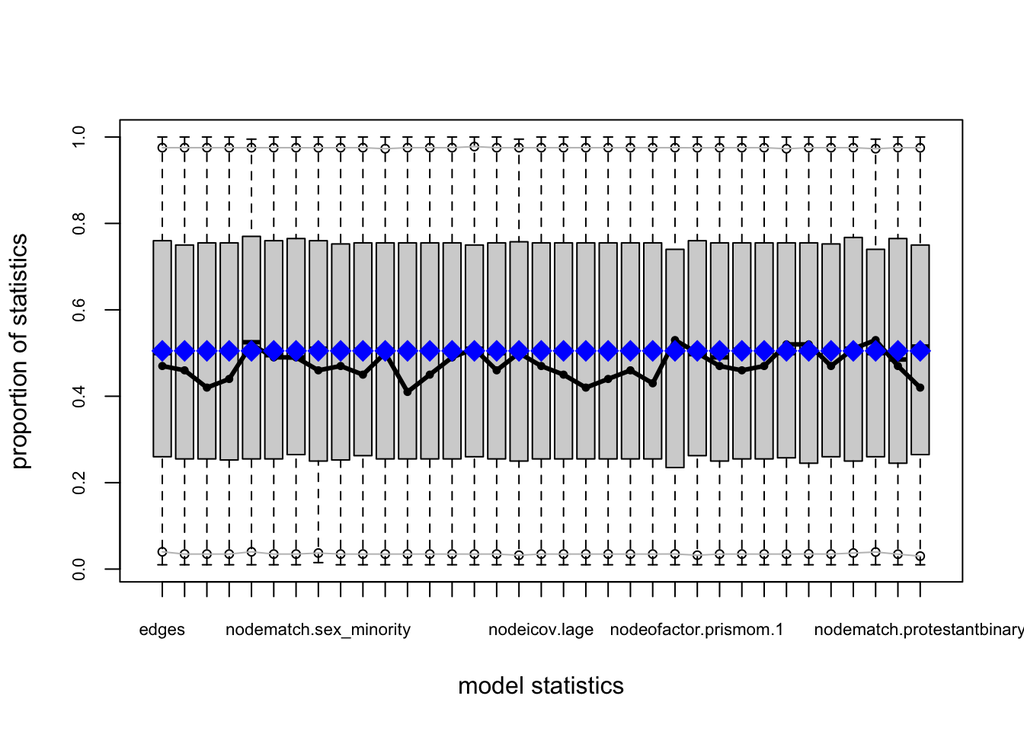

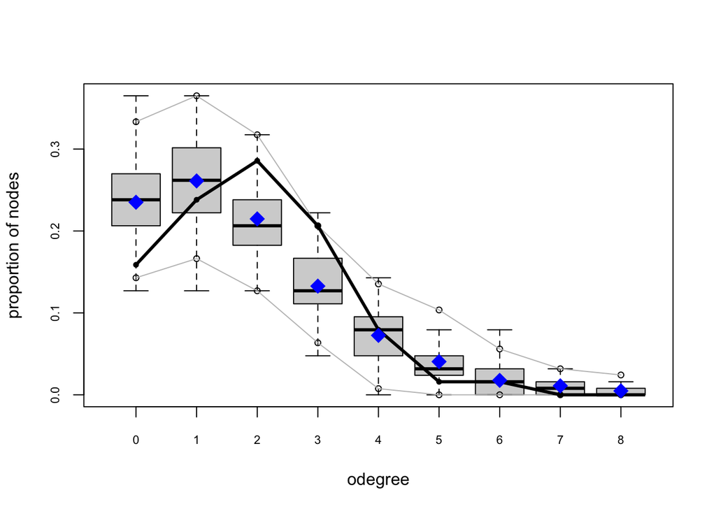

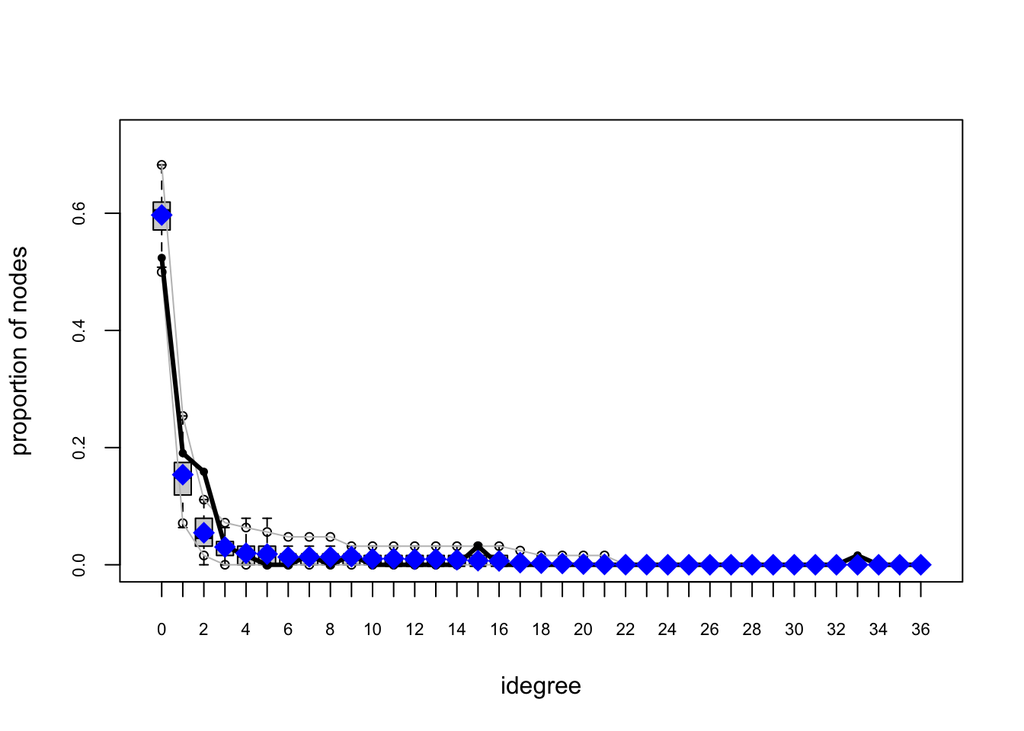

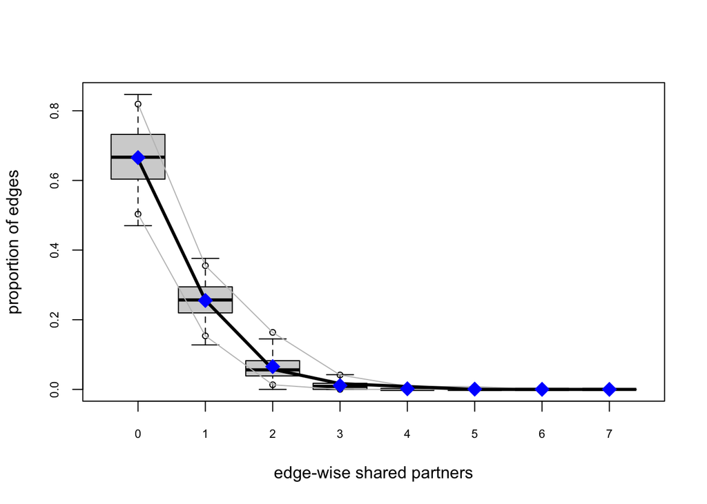

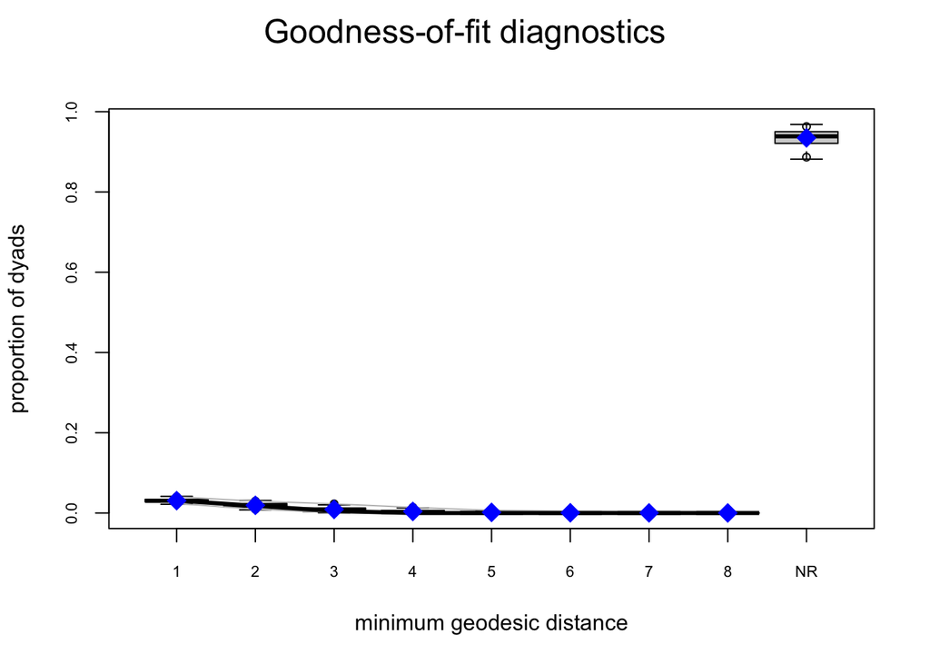

```
##
## Goodness-of-fit for in-degree
##
##           obs min  mean max MC p-value
## idegree0   22  17 24.52  33       0.52
## idegree1   13   3 11.37  17       0.80
## idegree2    9   2  6.06  10       0.26
## idegree3    5   0  3.59   8       0.50
## idegree4    2   0  2.52   6       1.00
## idegree5    1   0  1.83   5       0.80
## idegree6    0   0  1.56   6       0.40
## idegree7    1   0  1.12   4       1.00
## idegree8    0   0  0.83   3       0.88
## idegree9    0   0  0.69   3       0.92
## idegree10   0   0  0.48   3       1.00
## idegree11   0   0  0.34   3       1.00
## idegree12   2   0  0.28   2       0.10
## idegree13   0   0  0.26   2       1.00
## idegree14   0   0  0.17   1       1.00
## idegree15   0   0  0.21   2       1.00
## idegree16   0   0  0.06   1       1.00
## idegree17   0   0  0.01   1       1.00
## idegree18   1   0  0.02   1       0.04
## idegree19   0   0  0.04   1       1.00
## idegree20   0   0  0.01   1       1.00
## idegree21   0   0  0.03   1       1.00
##
## Goodness-of-fit for out-degree
##
##           obs min  mean max MC p-value
## odegree0   13   4 10.48  20       0.46
## odegree1   11   5 15.56  28       0.36
## odegree2   16   6 13.27  21       0.50
## odegree3    7   1  8.61  15       0.74
## odegree4    4   0  4.14  10       1.00
## odegree5    3   0  2.20   7       0.76
## odegree6    1   0  0.96   4       1.00
## odegree7    1   0  0.38   3       0.60
## odegree8    0   0  0.22   1       1.00
## odegree9    0   0  0.09   1       1.00
```

[output cut: 95 more lines]

```
## nodeicov.unitdays100                  0.74
## nodeocov.unitdays100                  0.96
## absdiff.unitdays100                   0.88
## nodeifactor.prismom.1                 0.98
## nodeofactor.prismom.1                 1.00
## nodematch.prismom                     0.90
## nodeicov.grade                        0.92
## nodeocov.grade                        0.94
## absdiff.grade                         0.92
## nodeifactor.white.1                   0.96
## nodeofactor.white.1                   0.88
## nodematch.white                       0.86
## nodeifactor.protestantbinary.1        0.84
## nodeofactor.protestantbinary.1        0.96
## nodematch.protestantbinary            0.94
```

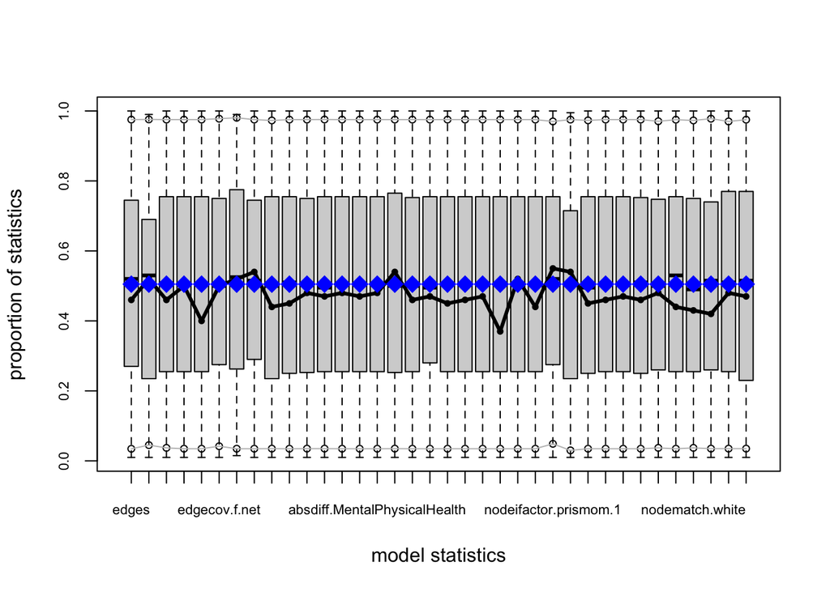

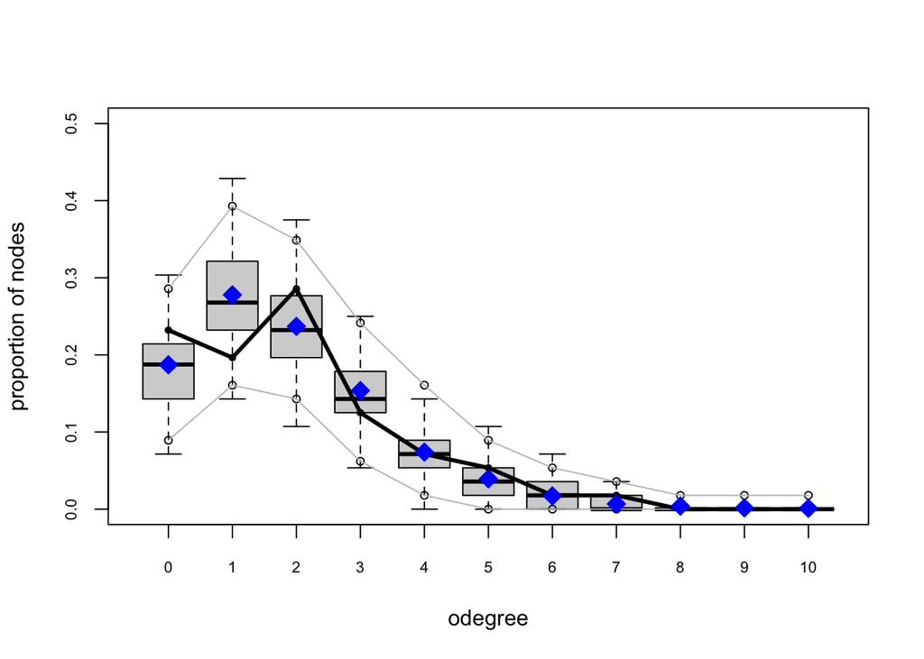

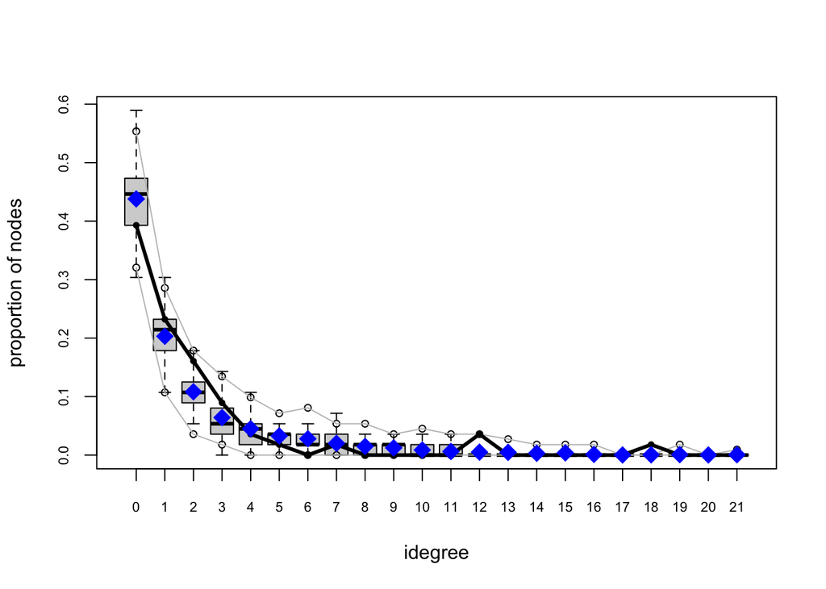

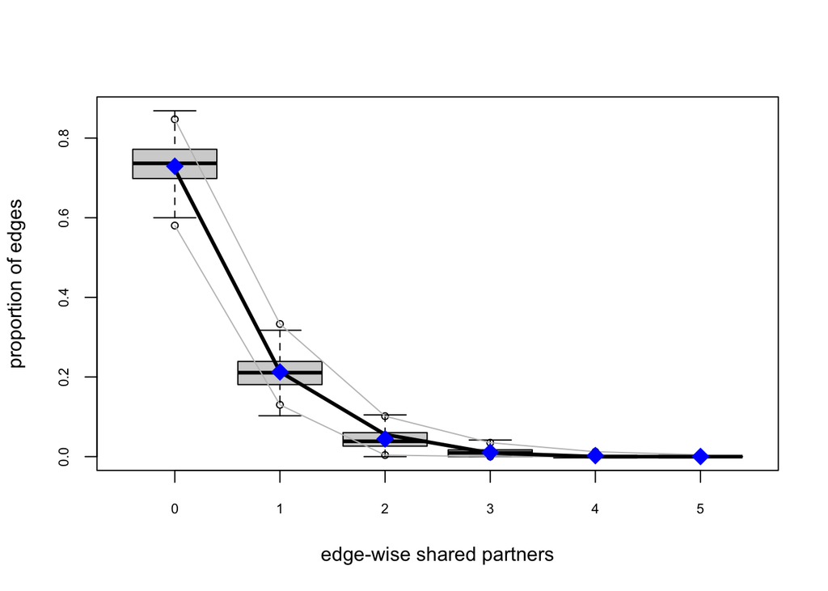

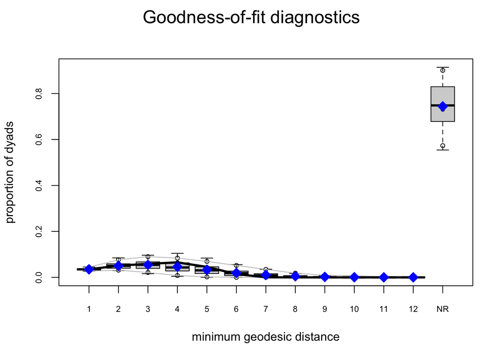

###### *Last updated 27 September, 2023*